# Bigram Language Model

Based on Andrej Karpathy's `makemore` library

## Data Generation

```python
# list = read_file + extract data into single line
words = open('names.txt', 'r').read().splitlines()
```

`<s>` and `<e>` are tokens indicating the start and end of a string respectively. **Note**: not adding the ", 0" would result in a KeyError if the combination is a first occurence.

```python
b = {} #frequent character combos
for word in words:
    chars = ['<s>'] + list(word) + ['<e>']
    for char1, char2 in zip(chars, chars[1:]): # consecutive characters; for bigram model
        bigram = (char1, char2)
        b[bigram] = b.get(bigram, 0) + 1 # if bigram exists, ++. Else, start from 0 and ++
```

lambda takes the kv tuple as input, returns it second element (count) as the key

```python
sorted(b.items(), key = lambda kv : kv[1], reverse = True)[:5] # only top 5
```

```
[(('n', '<e>'), 6763),
 (('a', '<e>'), 6640),
 (('a', 'n'), 5438),
 (('<s>', 'a'), 4410),
 (('e', '<e>'), 3983)]
```

### Optimising the code

#### 1. Storing data in `torch.tensor` instead of Python dictionary

1st element: row, 2nd element: column, value: no. of times 2nd element occurs after first

```python
import torch
```

```python
count = torch.zeros((28,28), dtype=torch.int32)
```

```python
stoi = {chr(i): i - 97 for i in range(97, 123)}
stoi['<s>'] = 26
stoi['<e>'] = 27
```

```python
for word in words:
   chars = ['<s>'] + list(word) + ['<e>']
   for char1, char2 in zip(chars, chars[1:]): # consecutive characters; for bigram model
       idx1 = stoi[char1]
       idx2 = stoi[char2]
       count[idx1, idx2] += 1
```

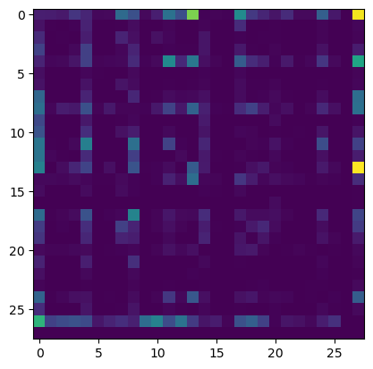

```python
import matplotlib.pyplot as plt
%matplotlib inline
plt.imshow(count)
```

#### 2. Reducing the Array size

Note how the 27th row, i.e., the row where `<e>` is the first character, is all zeros.  
Similarly, the 26th column, i.e., the one where `<s>` is the last character is all zeros.  
This means that the data we have can essentially be squeezed into a `27x27` grid, instead of `28x28` So, we're gonna remove `<s>` and `<e>` and replace it with `.` If `.` appears in a column, that means it's `<e>`. If in a row, then it's `<s>`

```python
count = torch.zeros((27,27), dtype=torch.int32)
```

```python
stoi = {chr(i): i - 96 for i in range(97, 123)} # starts from 1
stoi['.'] = 0
```

```python
for word in words:
    chars = ['.'] + list(word) + ['.'] # '.' indicates both start and end of string
    for char1, char2 in zip(chars, chars[1:]): # consecutive characters; for bigram model
        idx1 = stoi[char1]
        idx2 = stoi[char2]
        count[idx1, idx2] += 1
```

```python
itos = {i:s for s, i in stoi.items()}
```

### Timing Analysis between int32 and int16

```python
import time

n = int(1e6) # random dataset's size
a = torch.randint(0, 27, (n, ))
b = torch.randint(0, 27, (n, ))

# flatten the 2d indices into a single vector
flat_idx = 27*a + b # 27 = number of bins/row

def prfmnc_dtype (flat_idx, dtype):
    start = time.time()
    count = torch.bincount(flat_idx, minlength=27*27).to(dtype)
    count = count.reshape(27,27)
    end = time.time()
    return count, end-start

count16, t_int16 = prfmnc_dtype(flat_idx, torch.int16)
count32, t_int32 = prfmnc_dtype(flat_idx, torch.int32)

print(f"int16 time: {t_int16:.6f} seconds")
print(f"int32 time: {t_int32:.6f} seconds")
```

```
int16 time: 0.044595 seconds
int32 time: 0.024146 seconds
```

## Count Matrix

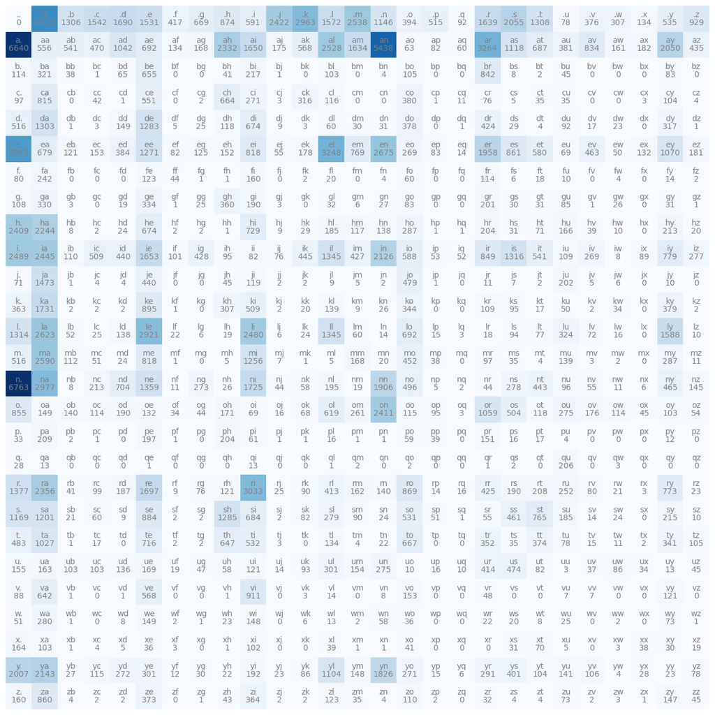

```python
import matplotlib.pyplot as plt
%matplotlib inline

plt.figure(figsize=(16,16))
plt.imshow(count, cmap = 'Blues')
for i in range (27):
    for j in range (27):
        chstr = itos[i] + itos[j]
        plt.text(j,i,chstr,ha="center",va="bottom",color="gray")
        plt.text(j,i,count[i,j].item(),ha="center",va="top",color="gray")
plt.axis('off');
```

This returns the probabilities of the characters `.`-`z` being the first character in the word. Since there aren't any zero-length words in our dataset, the probability for a zero-length word is zero.

```python
# time to play around a bit!
p = count[0, :].float() #count[0] would also work, btw
print(p)
p /= p.sum()
p
```

```
tensor([   0., 4410., 1306., 1542., 1690., 1531.,  417.,  669.,  874.,  591.,
        2422., 2963., 1572., 2538., 1146.,  394.,  515.,   92., 1639., 2055.,
        1308.,   78.,  376.,  307.,  134.,  535.,  929.])
```

```
tensor([0.0000, 0.1377, 0.0408, 0.0481, 0.0528, 0.0478, 0.0130, 0.0209, 0.0273,
        0.0184, 0.0756, 0.0925, 0.0491, 0.0792, 0.0358, 0.0123, 0.0161, 0.0029,
        0.0512, 0.0642, 0.0408, 0.0024, 0.0117, 0.0096, 0.0042, 0.0167, 0.0290])
```

```python
g = torch.Generator().manual_seed(2147483647)
idx = torch.multinomial(p, num_samples = 1, replacement=True, generator = g).item()
itos[idx]
```

```
'c'
```

Here, we generate the probability rows, and store them in `P` for later.

```python
P = (count+1).float() # +1 is for model smoothing, to ensure we don't run into 'inf's or '0's later on
rowwise_sums = torch.sum(input = P, dim = 1, keepdim = True) #keepdim = True ensures proper broadcasting.
print(rowwise_sums.T, rowwise_sums.shape)
P /= rowwise_sums
P[0] # to compare with what we manually did b4
```

```
tensor([[32060., 33912.,  2672.,  3559.,  5523., 20450.,   932.,  1954.,  7643.,
         17728.,  2927.,  5067., 13985.,  6669., 18354.,  7961.,  1053.,   299.,
         12727.,  8133.,  5597.,  3162.,  2600.,   956.,   724.,  9803.,  2425.]]) torch.Size([27, 1])
```

```
tensor([3.1192e-05, 1.3759e-01, 4.0767e-02, 4.8129e-02, 5.2745e-02, 4.7785e-02,
        1.3038e-02, 2.0898e-02, 2.7293e-02, 1.8465e-02, 7.5577e-02, 9.2452e-02,
        4.9064e-02, 7.9195e-02, 3.5777e-02, 1.2321e-02, 1.6095e-02, 2.9008e-03,
        5.1154e-02, 6.4130e-02, 4.0830e-02, 2.4641e-03, 1.1759e-02, 9.6070e-03,
        4.2109e-03, 1.6719e-02, 2.9008e-02])
```

### Necessity of Broadcasting- illustrative example

```python
testTensor = torch.tensor([[1,2],
                          [3,4]], dtype=torch.float32)
print("Our Tensor: ")
print(testTensor)
testTensor2 = testTensor

print("Proper Broadcating: row /= row_sum")
row_sum = torch.sum(input = testTensor, dim = 1, keepdim = True)
print(row_sum)
# 27, 27
# 27, 1
# would copy the row-value 27 times, and do element-wise division.
# so, each row-element gets divided by its row-sum -> good.
testTensor /= row_sum
print(testTensor)

print("Improper Broadcasting: column /= row_sum")
row_sum2 = torch.sum(input = testTensor2, dim = 1, keepdim = False)
print(row_sum2)
# 27, 27                                                   27, 27
#     27 (always align to the right) -> gets converted to:  1, 27 -> this is a 1 row, 27 column tensor
# would copy the column values 27 times, and then perform element wise division
# so, all elements of column-i will get divided by the sum of elements of row-i -> wrong.
testTensor2 /= row_sum2
print(testTensor2)
```

```
Our Tensor:
tensor([[1., 2.],
        [3., 4.]])
Proper Broadcating: row /= row_sum
tensor([[3.],
        [7.]])
tensor([[0.3333, 0.6667],
        [0.4286, 0.5714]])
Improper Broadcasting: column /= row_sum
tensor([1., 1.])
tensor([[0.3333, 0.6667],
        [0.4286, 0.5714]])
```

## Frequency-based Name Generation

`num_samples` = 1 -> only 1 character at a time  
`replacement = True` -> same character can be generated again and again  
`p` -> probability vector of samples in that row, i.e., P(letter) = `P[idx][letter]`  
`P[idx]` starts with `.`, and is then changed based on `torch.multinomial`'s output  
If it becomes `.` again, then it's the end of the word

```python
g = torch.Generator().manual_seed(2147483647)

for _ in range (10):
    idx = 0
    out = []
    while True:
        p = P[idx]
        idx = torch.multinomial(p, num_samples = 1, replacement=True, generator = g).item()
        if (idx == 0): # end of string
            break
        out.append(itos[idx])
    print(''.join(out))
```

```
cexze
momasurailezitynn
konimittain
llayn
ka
da
staiyaubrtthrigotai
moliellavo
ke
teda
```

The names might seem bad, but it's better than random

```python
g = torch.Generator().manual_seed(2147483647)

for _ in range (10):
    rand_idx = 0
    rand_out = []
    while True:
        p = torch.ones((27,27), dtype = torch.float32)[rand_idx]
        p /= p.sum()
        rand_idx = torch.multinomial(p, num_samples = 1, replacement=True, generator = g).item()
        if (rand_idx == 0): # end of string
            break
        rand_out.append(itos[rand_idx])
    print(''.join(rand_out))
```

```
cexzm
zoglkurkicqzktyhwmvmzimjttainrlkfukzkktda
sfcxvpubjtbhrmgotzx
iczixqctvujkwptedogkkjemkmmsidguenkbvgynywftbspmhwcivgbvtahlvsu
dsdxxblnwglhpyiw
igwnjwrpfdwipkwzkm
desu
firmt
gbiksjbquabsvoth
kuysxqevhcmrbxmcwyhrrjenvxmvpfkmwmghfvjzxobomysox
```

## Performance Evaluation

Probability of emma = `P(.e)` * `P(em)` * `P(mm)` * `P(ma)` * `P(a.)`. The others can be found out in a similar manner.  
So, P(dataset) = product of all such values -> likelihood of the dataset being output by our model -> maximise  
log(likelihood) used for convenience (`*` converted to `+`), also avoids smth like vanishing gradient -> maximise (-ve)  
Or, minimise (+ve) negative-log-likelihood (`nll`). take the avg to get avg loss -> that'll be your objective-function/performance-indicator

```python
nll = 0.0
n = 0
for word in words: # replace *words* with *['{string of your choice}']* to check how likely of an output that is!
    chs = ['.'] + list(word) + ['.']
    for ch1, ch2 in zip(chs, chs[1:]):
        ix1 = stoi[ch1]
        ix2 = stoi[ch2]
        prob = P[ix1, ix2] # probability that itos[ix2] occurs after itos[ix1]
        logprob = torch.log(prob)
        nll -= logprob
        n += 1
print(f'negative log likelihood (minimise, ideally 0) = {nll}')
print(f'avg = {nll/n}')
```

```
negative log likelihood (minimise, ideally 0) = 559951.5625
avg = 2.4543561935424805
```

## Neural Network based implementation

**GOAL**: `character` -> `[NN]` -> `P(next_char)`

```python
# create training set of all bigrams (x,y)

xs, ys = [], [] # inputs, targets
for word in words:
    chs = ['.'] + list(word) + ['.']
    for ch1, ch2 in zip(chs, chs[1:]):
        ix1 = stoi[ch1]
        ix2 = stoi[ch2]
        xs.append(ix1)
        ys.append(ix2)
        #print(f'{ch1}{ch2}')

xs = torch.tensor(xs)
ys = torch.tensor(ys)
num = xs.nelement()
print(f'Number of training samples: {num}')

# initialise the network
import torch.nn.functional as F

g = torch.Generator().manual_seed(2147483647)
W = torch.randn((27,27), generator=g, requires_grad=True)
```

```
Number of training samples: 228146
```

```python
#print(xs, ys, sep='\n')
#xs:0 -> ys: 5
#xs: 5 -> ys: 13, etc.
```

The equivalent to the smoothing we achieved (`counts + 1`) in the frequency-based approach can be done by incentivising `W` to be near 0  
`W = 0` -> `logits = 0` (log-counts) -> `counts = 1` -> `prob = uniform`  
We can then *regularise* the loss by adding a component to it in each pass that depends on the weights being away from 0  
We use `(W**2).mean()`, since just `(W**2)` would be too large.  
The proportion by which we add this to our loss is something called a regularisation parameter, say 0.01

```python
# training: gradient descent:
for _ in range (100):
    # forward-pass
    x_encoded = F.one_hot(xs, num_classes=27).float()
    logits = x_encoded @ W # log-counts
    counts = logits.exp() # to be interpreted like the actual counts we had earlier
    prob = counts/counts.sum(dim = 1, keepdim = True)
    # the last 2 lines implement "Softmax": input -> [e^input[i]/sum_i(e^input[i])] -> output
    # we use avg nll for loss
    loss = -prob[torch.arange(num), ys].log().mean() + 0.01*((W**2).mean())
    #print(loss.item())

    # backward pass
    W.grad = None # interpreted as 0
    loss.backward() # PyTorch keeps track of all of these; goes back all the way to W

    #update
    W.data -= 50*W.grad #learning rate determined by trial-and-error, don't stress much about the high value
```

`prob[torch.arange(num), ys]`  
Since the indexing above might be a bit confusing, let's break it down:

- `torch.arange(num)` -> generates an array of elements `[0,1,2..., num-1]`
- `ys` -> contains the target indices
- `prob[torch.arange(num), ys]` = `[prob[0, ys[0]], prob[1, ys[1]], prob[2, ys[2]], ..., prob[num-1, ys[num-1]]]`

This is essentially `P[target|input]` for all the inputs, with the indexing made easier by Pytorch.

### Alternate Approach:

```python
# nlls = torch.empty(prob.shape[0])
# for i in range (prob.shape[0]):
#     #i-th bigram
#     x = xs[i].item() # input character index
#     y = ys[i].item() # output character index
#     print()
#     print(f'Example {i+1}: {itos[x]}{itos[y]} [{x},{y}]')
#     print(f'Input to neural net: {x}, which maps to {itos[x]}')
#     print(f'output probabilities for this input: {prob[i]}')
#     print(f'target: {y}, which maps to {itos[y]}')
#     p = prob[i][y]
#     print(f'probability assigned to target: {p}')
#     nll = -torch.log(p)
#     print(f'negative-log-likelihood: {nll}')
#     nlls[i] = nll
#     print()
# print(f'avg nll (loss) = {nlls.mean()}')
```

```python
# print('Noob way of doing stuff: ')
# for i in range (5):
#     x = xs[i].item() # input
#     y = ys[i].item() # target
#     x_val = itos[x]
#     y_val = itos[y]
#     prob_x_y = prob[i][y]
#     print(f'Probability of {x_val}{y_val} = {prob_x_y}')
# print()
```

### Logic behind logits (log-counts)

```
testw = torch.randn((5,5))
input = torch.tensor([0,0,0,1,0]).float()
input @ testw
```

The one-hot column `i` picks out the i-th row of `testw` Or, we can say that the one-hot-encoded index `i` picks out a row containing the probabilites of all the other one-hot indexed characters

Input acts as lookup in logits table -> logits exponentiated to provide counts -> counts normalised to get probabilities!

```python
# onto sampling from the new-ral net model
g = torch.Generator().manual_seed(2147483647)
for _ in range (10):
    idx = 0
    out = []
    while True:
        #pick out a character
        x_encoded = F.one_hot(torch.tensor([idx]), num_classes=27).float()
        # pick out the one-hot-encoded row
        logits = x_encoded @ W
        counts = logits.exp()
        prob = counts/torch.sum(input = counts, dim = 1, keepdim = True)
        # sample the counts, output one character
        idx = torch.multinomial(prob, num_samples = 1, replacement=True, generator = g).item()
        if (idx == 0): # end of string
            break
        out.append(itos[idx])
    print(''.join(out))
```

```
cexze
momasurailezityha
konimittain
llayn
ka
da
staiyaubrtthrigotai
moliellavo
ke
teda
```

Note how the names generated here are very similar to the ones we got with the purely frequency-based model!